[figure not shown]

# Introduction to Time Series

Course Instructor: Nicole LEE ([LinkedIn](https://www.linkedin.com/in/nicoleleezhiying/))

30 Mar 2023 (0900 - 1730)

### Course Overview

Time series analysis is a statistical method that deals with data collected over time. It involves analysing and modelling data to identify patterns and trends, and make predictions about future values in the series. Time series data can be found in a wide range of fields, including economics, finance, and engineering:

- [IoT Sensor Predictions](https://www.timescale.com/blog/how-everactive-powers-a-dense-sensor-network-with-virtually-no-power-at-all/)
- Predictions of Financial Markets
- Prediction of macroeconomic factors which may contribute to business outcomes
- Understand sales patterns and predict future sales and revenue

[figure not shown]

In this 1-day course, you will learn about the basics of time series, data preparation of a time series dataset, visualization, modeling and forecasting to understand the underlying factors driving trends and provide impactful insights.

### Learning Objectives

1. Introduction to Time Series  
   1.1 Stationarity and Tests for Stationarity  
   1.2 Seasonality and Correlatation
2. Univariate Time Series Forecasting  
   2.1 Evaluation Metrics  
   2.2 Moving Average  
   2.3 Simple Exponential Smoothing, Holt's ES, Holt-Winter's ES  
   2.4 AR, MA, ARIMA, SARIMA, SARIMAX Models  
   2.4.1 Summary  
   2.6 Fourier Transformations
3. Multivariate Time Series Forecasting: VAR/VECM
4. Group Project

### Other Exercises to Try

1. Stock Price Prediction
   - Pick a stock of interest
   - Get price data from [Yahoo! Finance](https://sg.finance.yahoo.com/quote/%5EGSPC/history?p=%5EGSPC)
   - Identify characteristics of the time series
   - Plot short-term predictions of stock prices
2. HDB Pricing Trend
   - Download HDB Data from [data.gov.sg](https://data.gov.sg/dataset/resale-flat-prices)
   - Consider breaking data points into its town boundaries, flat type, storey range, proximity to a facility, etc. and investigate trends in housing prices.
3. Find datasets on UCI/Kaggle and practice

### 1. Introduction to Time Series

Time series is when a set of data points are chronologically collected over time. These allow us to identify changes of different types of data points over time.

[figure not shown]

Weather  
For instance, we notice that the average annual temperatures have risen over the last 80 years. We can also overlay the rainfall dataset to compare the average rainfall per month over years, to study if there has been a change in the *monsoon season* over the past 5 years.

[figure not shown]

Stock Market

[figure not shown]

Often, we see the stock prices rise and fall, reacting to various economic events. By stripping away the *noise* of the data, we will be able to gain a better understanding of the price trends or volatility trends. However, due to the various interactions between market participants, as well as concurrent micro and macro economic factors, it is often not possible to strip the stock prices data and understand the true drivers of a price surge or dip in prices.

Sale and Transaction Data  
We will notice spikes in sales during a sale period. When you imagine a traditional retail market, you notice that the holiday period sees a peak, resulting in a clear yearly peak.

```python
import os
import warnings

import numpy as np
import pandas as pd
import matplotlib.pyplot as plt
import pmdarima as pm
import statsmodels.tsa.api as tsa

from datetime import date, datetime, timedelta
from itertools import combinations
from sklearn.metrics import mean_absolute_error, mean_absolute_percentage_error, mean_squared_error
from statsmodels.graphics.tsaplots import plot_acf, plot_pacf
from statsmodels.tsa.statespace.sarimax import SARIMAX

warnings.filterwarnings('ignore')
warnings.simplefilter(action='ignore', category=FutureWarning)

DATA_DIR = "data/"
```

Use `%pip install <package>` to install missing packages

```python
## Download and understand the components of a time series dataset
passenger_data = pd.read_csv(os.path.join(DATA_DIR, "air_passengers.csv"))
passenger_data.tail(10)
```

|  | ds | y |
| --- | --- | --- |
| 134 | 1960-03-01 | 419 |
| 135 | 1960-04-01 | 461 |
| 136 | 1960-05-01 | 472 |
| 137 | 1960-06-01 | 535 |
| 138 | 1960-07-01 | 622 |
| 139 | 1960-08-01 | 606 |
| 140 | 1960-09-01 | 508 |
| 141 | 1960-10-01 | 461 |
| 142 | 1960-11-01 | 390 |
| 143 | 1960-12-01 | 432 |

### Characteristics of a Time Series

A time series dataset is characterised by the following:

[figure not shown]

These form the components of a time series.  
**Other terms which may be relevant include**:  
Lag  
Refers to the time difference between two related variables or time delay between a dependent and independent variable. By understanding lag, it helps us understand how one unit of change in one variable can affect another variable over time. By studying the relationship of lag and its variables, we can identify the data trends across time.

#### 1.1 Stationarity and Tests for Stationarity

Any time series dataset can be classified as stationary or non-stationarity,

- Stationary data refers to data where the statistical properties, such as mean and variance, remain constant over time. This means that the distribution of data points is consistent across all time periods, and there are no trends or patterns that change over time. Therefore, stationary time series or stationary processes are predictable. Analytical methodologies can be applied across all time periods in the data set.
- Non-stationary data refers to data whose statistical properties change over time. Hence, the trends, patterns or seasonality may differ and be difficult to predict over time.

Stationarity can be further broken down into the following:

Time series methodologies in this day course are most effective on stationarity data, which can be tested in 2 ways:

1. Visualization
2. Augmented Dickey Fuller Test

*Mathematically, this is represented as:*

1. Strong/Strict/Complete Stationarity
   Let us label a set of data points as $$\{X_t: t\in T\}$$ where $t$ is the index, or taken as time here and $T$ is the index set, which is the total time period we consider. $X$ can be univariate or multivariate, continuous or discrete.

   Now, $\{X_t\}$ is said to be completely stationary, if for all $n \geq 1$, for any $t_1, t_2, \dots, t_n \in T$ and for any lag $\tau$ such that $t_1+\tau, t_2+\tau, \dots, t_n+\tau \in T$ are also contained in the index set, the joint cdf $\{X_{t_1}, X_{t_2}, \dots, X_{t_n}\}$ is the same as that of $\{X_{t_{1+\tau}}, X_{t_{2+\tau}}, \dots, X_{t_{n+\tau}}\}$ Then, $$ F_{t_1, t_2, \dots, t_n}(a_1, a_2, \dots, a_n) = F_{t_(1+\tau), t_(2+\tau), \dots, t_(n+\tau)}(a_1, a_2, \dots, a_n)$$
   **A completely stationary process is invariant under a shift in time.**
2. Weak/second-order Stationarity
   Now, $\{X_t\}$ is said to be second-order stationary, if for all $n \geq 1$, for any $t_1, t_2, \dots, t_n \in T$ and for any lag $\tau$ such that $t_1+\tau, t_2+\tau, \dots, t_n+\tau \in T$ are also contained in the index set, all the joint moments of orders 1 and 2 of $\{X_{t_1}, X_{t_2}, \dots, X_{t_n}\}$ exist, are finite, and equal to the corresponding joint moments of $\{X_{t_{1+\tau}}, X_{t_{2+\tau}}, \dots, X_{t_{n+\tau}}\}$ Then, $$ E\{X_t\} \equiv \mu, \qquad var\{X_t\} \equiv \sigma^2 = E\{X_t^2\} - \mu^2$$ are constants independent of t. </i>

```python
rain_data = pd.read_csv(
    os.path.join(DATA_DIR, "201801_202302_PASIRPANJANG_RAIN.csv")
)
rain_data.head()
```

|  | Station | Year | Month | Day | Daily Rainfall Total (mm) | Mean Temperature (°C) | Maximum Temperature (°C) | Minimum Temperature (°C) | Mean Wind Speed (km/h) | Max Wind Speed (km/h) | Highest 30 min Rainfall (mm) | Highest 60 min Rainfall (mm) | Highest 120 min Rainfall (mm) |
| --- | --- | --- | --- | --- | --- | --- | --- | --- | --- | --- | --- | --- | --- |
| 0 | Pasir Panjang | 2018 | 1 | 1 | 54.6 | 25.2 | 27.0 | 23.5 | 10.1 | 30.6 | 12.6 | 15.6 | 24.2 |
| 1 | Pasir Panjang | 2018 | 1 | 2 | 2.8 | 25.8 | 28.0 | 24.8 | 9.0 | 27.0 | 1.6 | 2.2 | 2.8 |
| 2 | Pasir Panjang | 2018 | 1 | 3 | 0.0 | 26.8 | 31.1 | 24.8 | 8.6 | 25.2 | 0.0 | 0.0 | 0.0 |
| 3 | Pasir Panjang | 2018 | 1 | 4 | 1.8 | 26.9 | 29.5 | 24.9 | 9.7 | 39.6 | 1.6 | 1.6 | 1.6 |
| 4 | Pasir Panjang | 2018 | 1 | 5 | 18.6 | 26.4 | 28.3 | 24.2 | 6.1 | 20.9 | 8.4 | 11.4 | 16.8 |

```python
### All time series data should have a time-index. Clean the dataset such that it has a datetime-index
value_col = "Daily Rainfall Total (mm)"
rain_data['Date'] = pd.to_datetime(rain_data[['Year', 'Month', 'Day']])
### To return just date, try
# rain_data['Date'] = rain_data.apply(lambda x: date(x['Year'], x['Month'], x['Day']), axis=1)
# rain_data['Date'] = pd.to_datetime(rain_data[['Year', 'Month', 'Day']]).dt.date

### Set Time-Index for Time series related Studies
rain_data.set_index('Date', inplace=True) # rain_data = rain_data.set_index('Date')
rain_data.tail()
```

| Date | Station | Year | Month | Day | Daily Rainfall Total (mm) | Mean Temperature (°C) | Maximum Temperature (°C) | Minimum Temperature (°C) | Mean Wind Speed (km/h) | Max Wind Speed (km/h) | Highest 30 min Rainfall (mm) | Highest 60 min Rainfall (mm) | Highest 120 min Rainfall (mm) |
| --- | --- | --- | --- | --- | --- | --- | --- | --- | --- | --- | --- | --- | --- |
| 2023-02-24 | Pasir Panjang | 2023 | 2 | 24 | 0.0 | 28.0 | 31.9 | 25.9 | 18.1 | 56.5 | 0.0 | 0.0 | 0.0 |
| 2023-02-25 | Pasir Panjang | 2023 | 2 | 25 | 0.0 | 27.6 | 31.2 | 25.6 | 16.0 | 46.9 | 0.0 | 0.0 | 0.0 |
| 2023-02-26 | Pasir Panjang | 2023 | 2 | 26 | 0.0 | 27.5 | 31.4 | 25.4 | 20.2 | 55.0 | 0.0 | 0.0 | 0.0 |
| 2023-02-27 | Pasir Panjang | 2023 | 2 | 27 | 0.0 | 27.2 | 30.7 | 24.9 | 21.8 | 59.1 | 0.0 | 0.0 | 0.0 |
| 2023-02-28 | Pasir Panjang | 2023 | 2 | 28 | 151.6 | 24.8 | 27.1 | 22.3 | 23.0 | 50.7 | 23.8 | 41.2 | 64.8 |

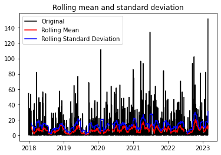

```python
### Consider the type of data and the appropriate size of a rolling window
### Consider trying a few values to determine if the dataset is indeed stationary
## Visual Stationarity Test
rolling_window = 30
# Experiment with various windows
rmean = rain_data[value_col].rolling(rolling_window).mean()
rstd = rain_data[value_col].rolling(rolling_window).std()

orig = plt.plot(rain_data[value_col], color="black", label="Original")
mean = plt.plot(rmean, color="red", label="Rolling Mean")
std = plt.plot(rstd, color="blue", label="Rolling Standard Deviation")
plt.legend(loc="best")
plt.title("Rolling mean and standard deviation")
plt.show(block=False)
```

```python
### Identify and fix missing value error - ADF does not run with null or inf values
rain_data.isnull().sum()
```

```
Station                           0
Year                              0
Month                             0
Day                               0
Daily Rainfall Total (mm)         3
Mean Temperature (°C)             1
Maximum Temperature (°C)          1
Minimum Temperature (°C)          1
Mean Wind Speed (km/h)           27
Max Wind Speed (km/h)            22
Highest 30 min Rainfall (mm)      4
Highest 60 min Rainfall (mm)      6
Highest 120 min Rainfall (mm)     6
dtype: int64
```

*Missing values*  
The 3 missing data points here are missing completely at random. These missing data points can be imputed via information in the dataset.  
Logically speaking, the highest recorded rainfall for a 2 hour window in the day is most indicative of the total rainfall for the entire day. Since they are not missing for 2 of the 3 values, we use the value in `Highest 120 min Rainfall (mm)`. For the remaining missing value with no values to impute, we can delete the data point (0.05% of the dataset).  
Note that if the data is 60% missing, you may opt to do a listwise deletion of the variable if it is insignificant.

```python
### Fix missing value error - ADF does not run with null or inf values
## Missing completely at random - Imputation via information in dataset
rain_data[value_col] = rain_data[value_col].fillna(rain_data['Highest 120 min Rainfall (mm)'])
rain_data.dropna(subset=[value_col], inplace=True)
```

#### Dickey Fuller Test

Null hypothesis, $H_0$: Dataset is not stationary.  
Alternative hypothesis, $H_1$: Dataset is stationary.  
Since -8.52 < -3.43, which is the t-value at 1% confidence level, the null hypothesis can be rejected and the data is stationary. Similarly, the p-value of $1.08^{10^{-13}}$ < 0.05 suggests that at 5% level of significance the null hypothesis can be rejected and is stationary.

If the series is non-stationary, often, it can be converted to a stationary series using a differencing method. We call this first layer of differencing as first differences, where $\Delta Y_t = Y_t - Y_{t-1}$.  
$d$ = number of differencing steps it takes for a dataset to achieve stationarity. Note that $d=0$ indicates a stationary series and $d>0$ indicates a non-stationary series  
This can be achieved by using `pd.DataFrame.diff()`  
Iteratively, take the difference of the dataset until stationarity is attained.  
Consider the use of KPSS for trend stationarity. Do take note of $H_0$ and $H_1$ of the KPSS test.

```python
def sm_adf(data, alpha = 0.05, **kwargs):
    """
    Function wrapping statsmodels' Augmented Dickey Fuller Test and prints the results accordingly. It takes the data and all arguments of the ADF test. For more information, refer to https://www.statsmodels.org/dev/generated/statsmodels.tsa.stattools.adfuller.html
    """
    kwargs['autolag'] = kwargs.get('autolag', 'AIC')
    indices = ["Test Statistic", "p-value", "#lags used", "number of observations used", "CV", kwargs['autolag']] if kwargs['autolag'] else ["Test Statistic", "p-value", "#lags used", "number of observations used", "CV"]
    df_output = pd.Series(
        tsa.adfuller(data, **kwargs),
        index=indices
    )
    critical_values = pd.Series(df_output.loc['CV'])
    critical_values.index = ['critical_value (%s)'%i for i in critical_values.index]
    df_output = pd.concat([df_output, critical_values]).drop('CV')
    stationary = df_output['p-value'] <= alpha
    if stationary:
        if np.sign(df_output['critical_value ({:.0%})'.format(alpha)]) < 0:
            assert df_output['Test Statistic'] <= df_output['critical_value ({:.0%})'.format(alpha)]
        else:
            assert df_output['Test Statistic'] >= df_output['critical_value ({:.0%})'.format(alpha)]
    return stationary, df_output

print(sm_adf(rain_data[value_col]))
```

```
(True, Test Statistic                    -8.524062
p-value                                 0.0
#lags used                               16
number of observations used            1867
AIC                            15102.297073
critical_value (1%)               -3.433857
critical_value (5%)               -2.863089
critical_value (10%)              -2.567595
dtype: object)
```

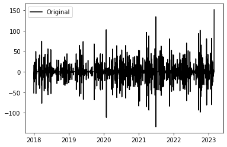

```python
### Form a stationary dataset from one of the sample datasets
rain_data_subset = rain_data[[value_col]].copy() # Remember to take a copy so that you are not editing the original dataset directly
rain_data_subset['Diffed'] = rain_data_subset.diff()

plt.plot(rain_data_subset[['Diffed']].dropna(), color="black", label="Original")
plt.legend(loc="best")
plt.show(block=False)
```

#### 1.2 Seasonality

- Seasonality refers to regular, predictable patterns that repeat over a fixed time interval, such as daily, weekly, monthly or yearly.
- It can be caused by various factors, including seasons, holidays, weather, human behaviour, etc.
- Often seasonality has different frequencies and the actual seasonality predicted from the historical data may differ from what one's expertise about a subject.

Methods to detect seasonality There are multiple methods of detecting seasonality, and/or cyclicity

- Visualize the data and not the periods of seasonality
- Use autocorrelation function (ACF) and partial auto-correlation function (PACF) plots to determine presence of seasonality
- Decompose time series into its trend, seasonality and residual components, allowing each component to be analysed individually

ACF and PACF plots  
**Autocorrelation Function (ACF)**: Measures how a series is correlated with itself at different lags.  
**Partial Autocorrelation Function (PACF)** Regression of the series against its past lags. The terms can be interpreted as the effect of a change in the particular lag, while holding all other variables constant.

```python
## Consider that the total rainfall per month is correlated. Then let us resample the data as monthly data
rain_month = rain_data[[value_col]].resample('1M').sum().rename(columns = {value_col: 'Total Rainfall'})
display(rain_month.head())

print("Stationarity Test for Total Monthly Rainfall")
stationary, adf_out = sm_adf(rain_month)
i = 1
while not stationary:
    stationary, adf_out = sm_adf(rain_month.diff(i).dropna())
    i += 1
print("Dataset is stationary at a 5% level of significance after {} differencing: {}".format(i-1, adf_out))
rain_month = rain_month.diff(i-1).dropna()
```

| Date | Total Rainfall |
| --- | --- |
| 2018-01-31 | 307.0 |
| 2018-02-28 | 43.6 |
| 2018-03-31 | 240.0 |
| 2018-04-30 | 154.8 |
| 2018-05-31 | 252.4 |

```
Stationarity Test for Total Monthly Rainfall
Dataset is stationary at a 5% level of significance after 1 differencing: Test Statistic                  -7.838231
p-value                               0.0
#lags used                              4
number of observations used            56
AIC                            594.493196
critical_value (1%)             -3.552928
critical_value (5%)             -2.914731
critical_value (10%)            -2.595137
dtype: object
```

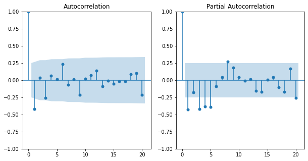

```python
### Plot ACF and PACF plots and take note of the lags and decay, which helps identify the components of the time series
_, acf_pacf_axs = plt.subplots(1,2,figsize=(10,5))
# lags refers to how far forward the graph plots
plot_acf(rain_month.squeeze(), lags=20, ax=acf_pacf_axs[0])
plot_pacf(rain_month.squeeze(), lags=20, ax=acf_pacf_axs[1])
plt.show()
# ARMA(0,1) - Non decaying PACF graph with decaying AR graph of significant lag at 1
```

For non-seasonal data, represented by $(p, d, q)$

|  | ACF | PACF |
| --- | --- | --- |
| AR(p) | Geometric Decay | Significant till $p$ lags |
| MA(q) | Significant till $q$ lags | Geometric Decay |

For seasonal data, represented by $(P, D, Q)m$

|  | ACF | PACF |
| --- | --- | --- |
| AR(p) | Geometric Decay | Significant at $P$ lags |
| MA(q) | Significant at $Q$ lags | Geometric Decay |

Time Series Decomposition  
The time series can also be decomposed into its components, as stated above, i.e. its trend, seasonality and residuals.  
In addition, the models can be classified as additive or multiplicative models:

- Additive models:
  $$Observation = trend + seasonality + residual$$ The magnitude of the seasonal and residual components are independent of the trend.
- Multiplicative models $$ Observation = trend \times seasonality \times residual$$ The multiplicative model has seasonal and/or residual plots which tend to follow the trend. They can be transformed into an additive model through a logarithmic transformation. $$ \therefore log(Observation) = log(time) + log(seasonality) + log(residual)
- Pseudo-additive models (*Extra*) Combines both additive and multiplicative models and are harder to spot.

*Note:* Identifying the right model is important in finding the right method to remove seasonality.

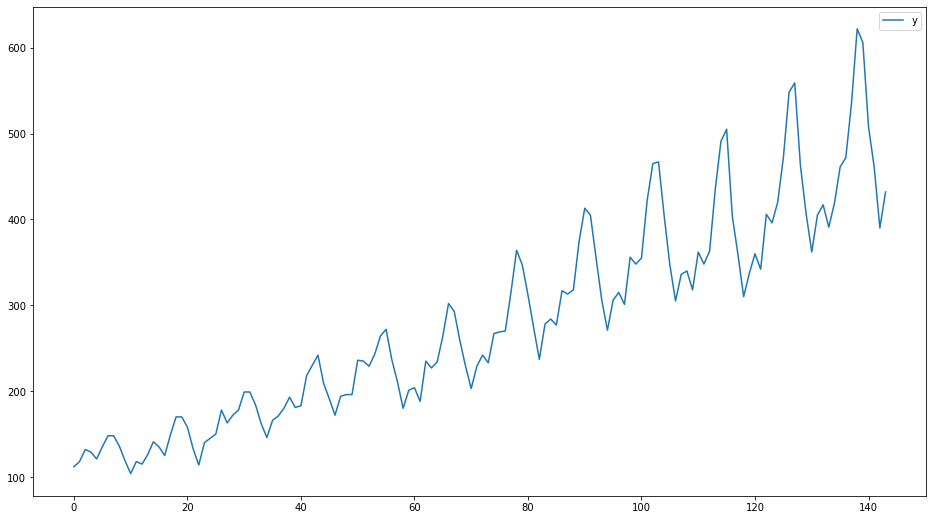

```python
passenger_data.plot(figsize=(16,9))
```

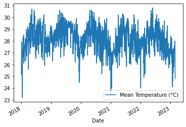

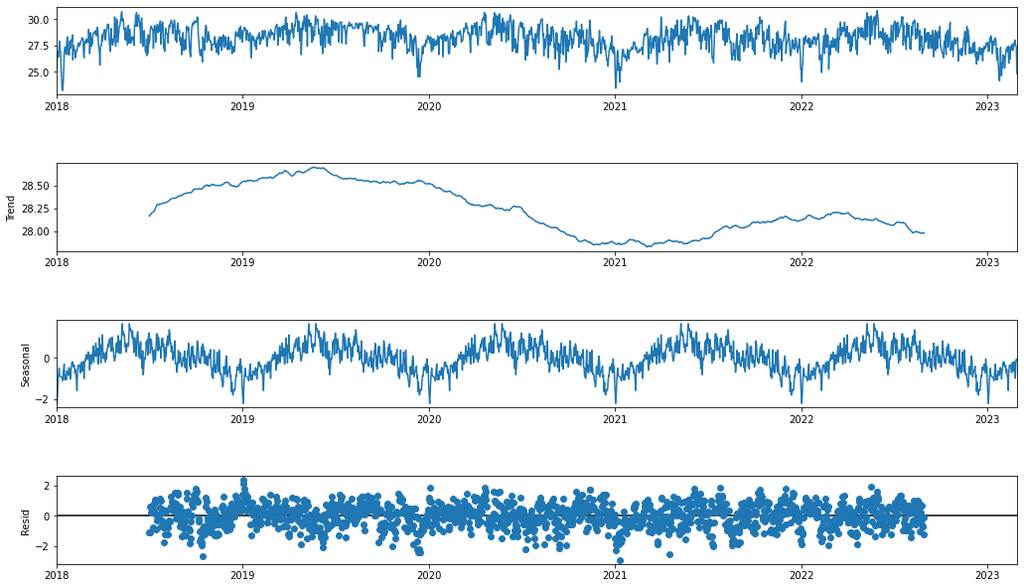

```python
# TS Decomposition
sg_temp = rain_data[['Mean Temperature (°C)']].copy().dropna()
sg_temp.plot()

decomposed_ts = tsa.seasonal_decompose(sg_temp, period=365)
white_noise = decomposed_ts.resid
fig = decomposed_ts.plot()
fig.set_size_inches((16, 9))
fig.show()
# print("Trend: {}".format(decomposed_ts.trend))
# print("Seasonal: {}".format(decomposed_ts.seasonal))
# print("White Noise: {}".format(white_noise))
# print("Observed Values: {}".format(decomposed_ts.observed))
```

### 2. Univariate Time Series Forecasting Methods

Given that we now know stationarity, and seasonality and the ways to detect then, we want to forecast the data based on its historical trends.

We explore several statistical techniques in this section.

#### 2.1 Evaluation Metrics

- MSE or Root MSE (RMSE)
  $$\frac{1}{T} \sum_{t=1}^T (F_t - Y_t)^2, $$ where $F_t$ is the forecasted value at time $t$ and $Y_t$ the actual value at time $t$.
- Mean absolute deviation (MAD)
  $$\frac{1}{T}\sum_{t=1}^T |F_t - Y_t|,$$ where $F_t$ is the forecasted value at time $t$ and $Y_t$ the actual value at time $t$.
- Mean absolute percentage error (MAPE)
  $$\frac{1}{T}\sum_{t=1}^T |\frac{F_t - Y_t}{Y_t}|,$$ where $F_t$ is the forecasted value at time $t$ and $Y_t$ the actual value at time $t$.

MAPE is unit free, and therefore ideal for comparing models.

#### 2.2 Moving Average: MA(n)

Method used to smooth out fluctuations, also known as the "rolling average", therefore removing the effects of seasonality.

The number of periods used to compute the moving/rolling average is known as the "window size" or "lag".

As n gets larger, the model is more robust and reflects the overall trend.

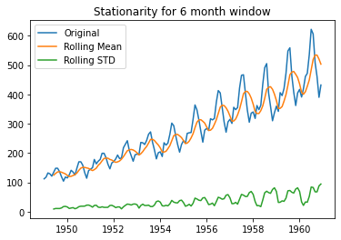

```python
### Use pd.DataFrame.rolling() to experiment with the moving averages
passenger_data['ds'] = pd.to_datetime(passenger_data['ds'])
passenger_data.set_index('ds', inplace=True)
passenger_mean = passenger_data.rolling(6).mean()
passenger_std = passenger_data.rolling(6).std()

plt.plot(passenger_data, label='Original')
plt.plot(passenger_mean, label='Rolling Mean')
plt.plot(passenger_std, label='Rolling STD')
plt.title('Stationarity for {} month window'.format(6))
plt.legend()
plt.show()
```

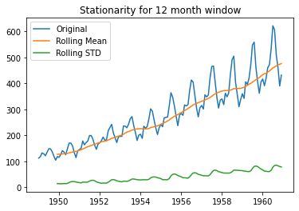

```python
### Use pd.DataFrame.rolling() to experiment with the moving averages
passenger_mean = passenger_data.rolling(12).mean()
passenger_std = passenger_data.rolling(12).std()

plt.plot(passenger_data, label='Original')
plt.plot(passenger_mean, label='Rolling Mean')
plt.plot(passenger_std, label='Rolling STD')
plt.title('Stationarity for {} month window'.format(12))
plt.legend()
plt.show()
```

#### 2.3 Exponential Smoothing Methods (ES)

- Gives more weight to recent observations, and less weight to older observations
- Utilises a weighted average, instead of a simple average in MA
- As events get older, the weights get exponentially smaller
- Particularly useful when there is no clear seasonality

Holt's Exponential Smoothing (Holt's ES)
$$ F_{t+p} = L_t + pT_t$$ $$ L_t = \alpha Y_t + (1 - \alpha)(L_{t-1} + T_{t-1})$$ $$ T_t = \beta(L_t - L_{t-1}) + (1 - \beta)T_{t-1},$$

where $F_{t+p}$ is a forecasted value for p time periods away, $L_t$ is the level (or intercept) for time $t$, and $T_t$ is the trend (or slope) at time $t$.

- Extension of SES, taking into account the linear trend
- **Two** smoothing parameters, one for level and other for trend
- Particularly useful for data with a clear trend but no clear seasonality

Winter's Exponential Smoothing
$$L_t = \alpha \frac{Y_t}{S_{t-s}} + (1-\alpha)(L_{t-1} + T_{t-1})$$ $$S_t = \gamma \frac{Y_t}{L_t} + (1 - \gamma) S_{t-s}$$ $$ T_t = \beta(L_t - L_{t-1}) + (1 - \beta)T_{t-1}$$ $$F_{t+p} = (L_t + pT_t)S_{t-s+p}$$

- Extends from Holt's ES, by adding a seasonal component.
- **Three** smoothing parameters, $\alpha, \beta, \gamma$ for level, trend and seasonality respectively.

```python
goog_train = pd.read_csv(os.path.join(DATA_DIR, "goog_train.csv"))
goog_test = pd.read_csv(os.path.join(DATA_DIR, "goog_test.csv"))
```

```
900    767.881318
901    767.881318
902    767.881318
903    767.881318
904    767.881318
          ...
995    767.881318
996    767.881318
997    767.881318
998    767.881318
999    767.881318
Length: 100, dtype: float64
```

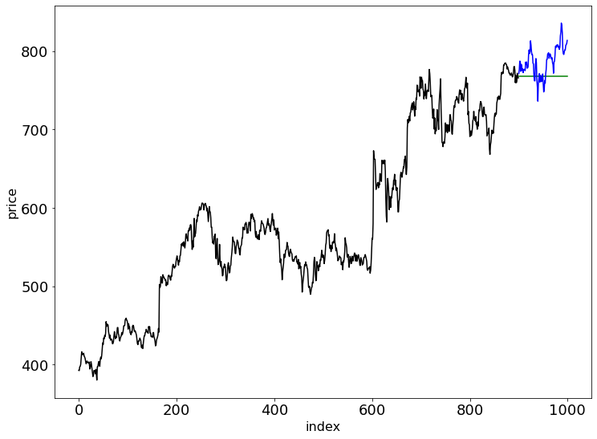

```python
### SES is suitable for data with no trend or seasonal pattern.
### forecast forward 100 steps with smoothing_level = 0.2

SES_model = tsa.SimpleExpSmoothing(goog_train['x']).fit(smoothing_level = 0.2)
print(SES_model.forecast(100))

### Plot Original values and its forecasted values
fig, ax1 = plt.subplots(figsize=(12, 9))
ax1.plot( list(goog_train.index), goog_train['x'],linestyle = 'solid', color = 'black', markersize = 1)
ax1.plot( list(SES_model.forecast(100).index), SES_model.forecast(100),linestyle = 'solid',color = 'green', markersize = 1)
ax1.plot( list(goog_test.index+goog_train.index.max()+1), goog_test['x'],linestyle = 'solid', color = 'blue', markersize = 1)
ax1.ticklabel_format(axis = 'y', style= 'sci',scilimits =(0,3))
ax1.set_xlabel('index',fontsize=16)
ax1.set_ylabel('price',fontsize=16)
plt.tick_params(labelsize=18)
plt.show()
```

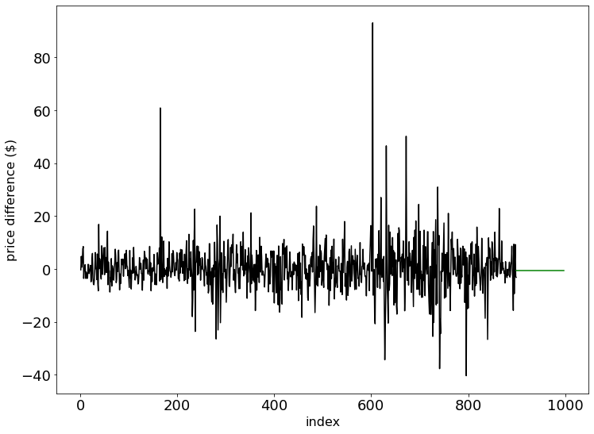

```python
### SES should not be used on data with a trend or seasonal component.
### Practice differencing to remove trends. Consider using .diff()

goog_train['diff'] = goog_train['x'].diff()
SES_diff_model = tsa.SimpleExpSmoothing(goog_train['diff'].dropna()).fit(smoothing_level = 0.2, optimized=True)
fig, ax1 = plt.subplots(figsize=(12, 9))
ax1.plot( list(goog_train.index), goog_train['diff'],linestyle = 'solid', color = 'black', markersize = 1)
ax1.plot( list(SES_diff_model.forecast(100).index), SES_diff_model.forecast(100),linestyle = 'solid',color = 'green', markersize = 1)
ax1.ticklabel_format(axis = 'y', style= 'sci',scilimits =(0,3))
ax1.set_xlabel('index',fontsize=16)
ax1.set_ylabel('price difference ($)',fontsize=16)
plt.tick_params(labelsize=18)
plt.show()
```

```python
### Import various metrics from sklearn and experiment with them
actual = pd.concat([goog_train, goog_test])['x'].diff()[900:]
forecasted = SES_diff_model.forecast(100)
MAD_SES = mean_absolute_error(
    forecasted, actual
)
print("MAD of Simple Exponential Smoothing on differenced time series:", MAD_SES)
MSE_SES = mean_squared_error(
    forecasted, actual
)
print("MSE of Simple Exponential Smoothing on differenced time series:", MSE_SES)
MAPE_SES = mean_absolute_percentage_error(
    forecasted, actual
)
print("MAPE of Simple Exponential Smoothing on differenced time series:", MAPE_SES)
```

```
MAD of Simple Exponential Smoothing on differenced time series: 6.1188606586008145
MSE of Simple Exponential Smoothing on differenced time series: 66.01165460861361
MAPE of Simple Exponential Smoothing on differenced time series: 11.22054767657224
```

```
900    766.116439
901    766.532866
902    766.949293
903    767.365720
904    767.782148
          ...
995    805.677013
996    806.093440
997    806.509868
998    806.926295
999    807.342722
Length: 100, dtype: float64
```

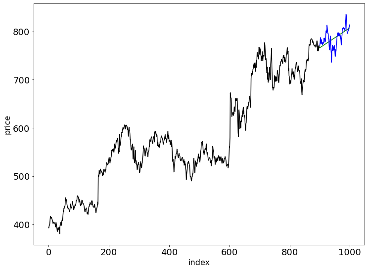

```python
### Try Holt's ES and forecast forward 100 steps.
holt_model = tsa.Holt(goog_train['x']).fit()
print(holt_model.forecast(100))

### Plot Original values and its forecasted values
fig, ax1 = plt.subplots(figsize=(12, 9))
ax1.plot( list(goog_train.index), goog_train['x'],linestyle = 'solid', color = 'black', markersize = 1)
ax1.plot( list(holt_model.forecast(100).index), holt_model.forecast(100),linestyle = 'solid',color = 'green', markersize = 1)
ax1.plot( list(goog_test.index+goog_train.index.max()+1), goog_test['x'],linestyle = 'solid', color = 'blue', markersize = 1)
ax1.ticklabel_format(axis = 'y', style= 'sci',scilimits =(0,3))
ax1.set_xlabel('index',fontsize=16)
ax1.set_ylabel('price',fontsize=16)
plt.tick_params(labelsize=18)
plt.show()
```

```python
### Import various metrics from sklearn and experiment with them
actual_diff = goog_test['x']
forecasted_holt = holt_model.forecast(100)
MAD_holt = mean_absolute_error(
    forecasted_holt, actual_diff
)
print("MAD of Simple Exponential Smoothing on the time series:", MAD_holt)
MSE_holt = mean_squared_error(
    forecasted_holt, actual_diff
)
print("MSE of Simple Exponential Smoothing on the time series:", MSE_holt)
MAPE_holt = mean_absolute_percentage_error(
    forecasted_holt, actual_diff
)
print("MAPE of Simple Exponential Smoothing on the time series:", MAPE_holt)
```

```
MAD of Simple Exponential Smoothing on the time series: 12.862256284297755
MSE of Simple Exponential Smoothing on the time series: 267.3618762492084
MAPE of Simple Exponential Smoothing on the time series: 0.016387890618262416
```

```python
holt_model_diff = tsa.Holt(goog_train['diff'][1:]).fit()
### Import various metrics from sklearn and experiment with them
forecasted_holt_diff = holt_model_diff.forecast(100)
MAD_holt_diff = mean_absolute_error(
    forecasted_holt_diff, actual
)
print("MAD of Simple Exponential Smoothing on the differenced time series:", MAD_holt_diff)
MSE_holt_diff = mean_squared_error(
    forecasted_holt_diff, actual
)
print("MSE of Simple Exponential Smoothing on the differenced time series:", MSE_holt_diff)
MAPE_holt_diff = mean_absolute_percentage_error(
    forecasted_holt_diff, actual
)
print("MAPE of Simple Exponential Smoothing on the differenced time series:", MAPE_holt_diff)
```

```
MAD of Simple Exponential Smoothing on the differenced time series: 6.009764424389345
MSE of Simple Exponential Smoothing on the differenced time series: 64.96772304267898
MAPE of Simple Exponential Smoothing on the differenced time series: 14.578858167971923
```

```
229    2.373332
230    2.547771
231    2.449661
232    2.113300
233    2.405473
dtype: float64
```

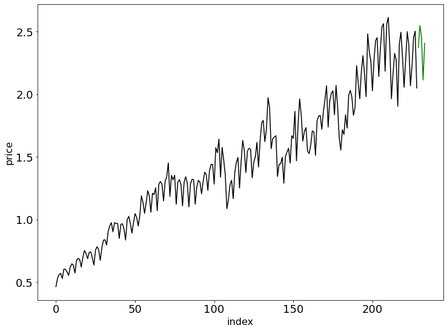

```python
### Try your hand at Holt-Winter's ES and forecast forward 100 steps.
qcement = pd.read_csv(os.path.join(DATA_DIR, 'qcement.csv'))
qcement_train = qcement[:-4]
qcement_test = qcement[-4:]

es_model = tsa.ExponentialSmoothing(
    qcement_train['x'],
    trend='add',
    seasonal='add',
    seasonal_periods = 4
).fit()

print(es_model.forecast(5))

### Plot Original values and its forecasted values
fig, ax1 = plt.subplots(figsize=(12, 9))
ax1.plot( list(qcement_train.index), qcement_train['x'],linestyle = 'solid', color = 'black', markersize = 1)
ax1.plot( list(es_model.forecast(5).index), es_model.forecast(5),linestyle = 'solid',color = 'green', markersize = 1)
ax1.ticklabel_format(axis = 'y', style= 'sci',scilimits =(0,3))
ax1.set_xlabel('index',fontsize=16)
ax1.set_ylabel('price',fontsize=16)
plt.tick_params(labelsize=18)
plt.show()
```

```python
es_model.summary()
```

ExponentialSmoothing Model Results

| Dep. Variable: | x | No. Observations: | 229 |
| --- | --- | --- | --- |
| Model: | ExponentialSmoothing | SSE | 1.605 |
| Optimized: | True | AIC | -1119.907 |
| Trend: | Additive | BIC | -1092.438 |
| Seasonal: | Additive | AICC | -1118.898 |
| Seasonal Periods: | 4 | Date: | Mon, 10 Apr 2023 |
| Box-Cox: | False | Time: | 18:26:45 |
| Box-Cox Coeff.: | None |  |  |

|  | coeff | code | optimized |
| --- | --- | --- | --- |
| smoothing_level | 0.6176775 | alpha | True |
| smoothing_trend | 1.5487e-16 | beta | True |
| smoothing_seasonal | 0.2120284 | gamma | True |
| initial_level | 0.5120811 | l.0 | True |
| initial_trend | 0.0080355 | b.0 | True |
| initial_seasons.0 | -0.0568441 | s.0 | True |
| initial_seasons.1 | 0.0144496 | s.1 | True |
| initial_seasons.2 | 0.0210220 | s.2 | True |
| initial_seasons.3 | -0.0051802 | s.3 | True |

#### 2.4 Models for Time Series datasets

Autoregressive Integrated Moving Average (ARIMA) - Linear models which can represent time series data (including non-stationary)  
ARIMA models do not involve independent variables and use information in the series to generate forecasts.

Autoregressive (AR) Model
$AR(p)$: Uses previous $p$ (also called order of AR model) values to predict the future values $$ Y_t = \phi_0 + \phi_1 Y_{t-1} + \dots + \phi_p Y_{t-p} + \epsilon_t,$$ where $\epsilon_t$ represents the white noise, $\{\phi_i\}_{i=1}^p$ are coefficients to estimate, and $Y_{i}$ are the values at time $i$ *Stationary time series can be represented by $AR(1)$*

Moving Average (MA) Model
$MA(q)$: Uses previous $p$ (also called order of AR model) error terms to predict the future values $$ Y_t = \mu + \epsilon_t + \theta_1 \epsilon_{t-1} + \dots + \theta_q \epsilon_{t-q} \implies Y_t - \mu = \epsilon_t + \sum_{i = 1}^q \theta_i \epsilon_{t-i},$$ where $\epsilon_t$ represents the white noise, $\{\theta_i\}_{i=1}^q$ are coefficients to estimate, and $Y_{i}$ are the values at time $i$
The deviation of the actual value at time t, is equal to the sum of current and past errors.

*Consider $MA(1) \equiv AR(\infty)$*

```python
### AR model
train_pass_data = passenger_data[:round(0.7*len(passenger_data))]
test_pass_data = passenger_data[round(0.7*len(passenger_data)):]

### Fit AR model
model_ar_pass = tsa.AutoReg(train_pass_data['y'], lags=3).fit()

### Make Predictions
ar_pass_predictions = model_ar_pass.predict(
    start=len(train_pass_data), end=len(train_pass_data) + len(test_pass_data) - 1
)

print(
    "Mean Squared Error for a MA model is {}".format(
        mean_squared_error(test_pass_data, ar_pass_predictions)
    )
)
```

```
Mean Squared Error for a MA model is 21984.382637984294
```

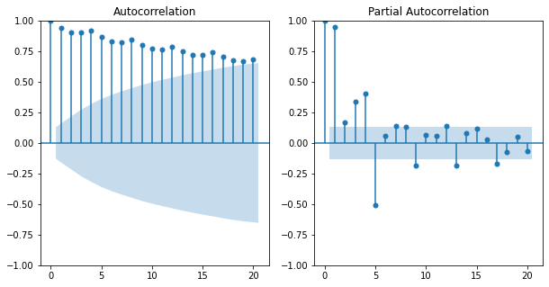

```
                            AutoReg Model Results
==============================================================================
Dep. Variable:                      x   No. Observations:                  229
Model:              Restr. AutoReg(5)   Log Likelihood                 204.857
Method:               Conditional MLE   S.D. of innovations              0.097
Date:                Mon, 10 Apr 2023   AIC                           -399.714
Time:                        18:26:45   BIC                           -382.655
Sample:                             5   HQIC                          -392.828
                                  229
==============================================================================
                 coef    std err          z      P>|z|      [0.025      0.975]
------------------------------------------------------------------------------
const          0.0358      0.020      1.804      0.071      -0.003       0.075
x.L1           0.6630      0.052     12.761      0.000       0.561       0.765
x.L4           0.8252      0.043     19.253      0.000       0.741       0.909
x.L5          -0.5049      0.059     -8.562      0.000      -0.621      -0.389
                                    Roots
=============================================================================
                  Real          Imaginary           Modulus         Frequency
-----------------------------------------------------------------------------
AR.1           -1.0577           -0.0000j            1.0577           -0.5000
AR.2            0.0099           -1.0557j            1.0558           -0.2485
AR.3            0.0099           +1.0557j            1.0558            0.2485
AR.4            1.0117           -0.0000j            1.0117           -0.0000
AR.5            1.6605           -0.0000j            1.6605           -0.0000
-----------------------------------------------------------------------------
Mean Squared Error for a MA model is 0.054264472336307705
```

```python
### AR model
train_data = qcement_train[['x']].copy()
test_data = qcement_test[['x']].copy()

_, acf_pacf_axs = plt.subplots(1,2,figsize=(10,5))
# lags refers to how far forward the graph plots
plot_acf(train_data.squeeze(), lags=20, ax=acf_pacf_axs[0])
plot_pacf(train_data.squeeze(), lags=20, ax=acf_pacf_axs[1])
plt.show()

## Fit AR model
model_ar = tsa.AutoReg(train_data, lags=[1, 4, 5])
model_ar_fit = model_ar.fit()

print(model_ar_fit.summary())

# ### Make Predictions
ar_predictions = model_ar_fit.predict(
    start=len(train_data), end=len(train_data) + len(test_data) - 1
)

print(
    "Mean Squared Error for a MA model is {}".format(
        mean_squared_error(test_data, ar_predictions)
    )
)
```

```python
### MA Model
model_ma = tsa.ARIMA(train_data, order=(0, 0, 4)) #order for p and d are 0
model_ma_fit = model_ma.fit()

ma_predictions = model_ma_fit.predict(
    start=len(train_data), end=len(train_data) + len(test_data) - 1
)

print(
    "Mean Squared Error for a MA model is {}".format(
        mean_squared_error(test_data, ma_predictions)
    )
)
```

```
Mean Squared Error for a MA model is 0.456983716668747
```

ARIMA Model  
**$ARIMA(p,d,q)$**: Combines AR and MA models, where

- $p$: Order of the AR model,
- $d$: Order of differencing (to make time series stationary),
- $q$: Order of MA model

SARIMA Model  
**$SARIMA(p,d,q)\times(P,D,Q)_s$**: Extension of ARIMA model which accounts for seasonality. AR and MA models, where

- $p$: Order of the AR model,
- $d$: Order of differencing (to make time series stationary),
- $q$: Order of MA model
- $P$: Seasonal order of AR model,
- $D$: Seasonal order of differencing,
- $Q$: Seasonal order of MA model
- $s$: Seasonal period

Additionally, it would be good to know that the following models which account for external factors exist but will not be covered in today's session  
*ARIMAX Model* **$ARIMAX(p,d,q,x)$**: "X" stands for Exogenous Variables, which extends the ARIMA model to account for the impact of external variables on the time series, where x represents the external variable.

- $p$: Order of the AR model,
- $d$: Order of differencing (to make time series stationary),
- $q$: Order of MA model
- $P$: Seasonal order of AR model,
- $D$: Seasonal order of differencing,
- $Q$: Seasonal order of MA model
- $s$: Seasonal period

```python
### ARIMA Model
model_arima = tsa.ARIMA(train_data, order=(5,1,4))
model_arima_fit = model_arima.fit()

arima_predictions = model_arima_fit.predict(
    start=len(train_data), end=len(train_data) + len(test_data) - 1
)

print(
    "Mean Squared Error for a ARIMA model is {}".format(
        mean_squared_error(test_data, arima_predictions)
    )
)
```

```
Mean Squared Error for a ARIMA model is 0.026631506090517867
```

```python
### SARIMA Model
model_sarima = SARIMAX(train_data)#, order=(5,1,4), seasonal=True)
model_sarima_fit = model_sarima.fit()
print(model_sarima_fit.summary())

sarima_predictions = model_sarima_fit.predict(
    start=len(train_data), end=len(train_data) + len(test_data) - 1
)

print(
    "Mean Squared Error for a SARIMA model is {}".format(
        mean_squared_error(test_data, sarima_predictions)
    )
)
```

```
                               SARIMAX Results
==============================================================================
Dep. Variable:                      x   No. Observations:                  229
Model:               SARIMAX(1, 0, 0)   Log Likelihood                  93.098
Date:                Mon, 10 Apr 2023   AIC                           -182.195
Time:                        18:26:46   BIC                           -175.328
Sample:                             0   HQIC                          -179.425
                                - 229
Covariance Type:                  opg
==============================================================================
                 coef    std err          z      P>|z|      [0.025      0.975]
------------------------------------------------------------------------------
ar.L1          0.9983      0.003    342.298      0.000       0.993       1.004
sigma2         0.0253      0.002     11.699      0.000       0.021       0.030
===================================================================================
Ljung-Box (L1) (Q):                  14.87   Jarque-Bera (JB):                 3.15
Prob(Q):                              0.00   Prob(JB):                         0.21
Heteroskedasticity (H):               6.07   Skew:                            -0.19
Prob(H) (two-sided):                  0.00   Kurtosis:                         3.44
===================================================================================

Warnings:
[1] Covariance matrix calculated using the outer product of gradients (complex-step).
Mean Squared Error for a SARIMA model is 0.22517518536150716
```

You can also consider installing pmdarima, which is the Python's version of R's auto.arima  
`!pip install pmdarima`

`from pmdarima install auto_arima`

#### Mini Activity

1. Ingest the tractor sales dataset
2. Remove trends, for both mean and variance
3. Plot ACF and PACF to identify potential AR and MA model
4. Check `model.summary()`
5. Forecast sales using the best fit ARIMA model
6. Plot ACF and PACF for residuals of ARIMA model to ensure no more information is left for extraction

```python
### Code here
### 1.
sales = pd.read_csv(
    os.path.join(DATA_DIR, "Tractor-Sales.csv")
 )
display(sales.head())
print("Tractor sales has {} data points".format(len(sales)))
print("Null values in Tractor Sales are:\n", sales.isnull().sum())

## Cleaning Date
sales['Date'] = pd.to_datetime(sales['Month-Year'], format='%b-%y')
sales = sales.drop(columns = ['Month-Year']).set_index('Date')
```

|  | Month-Year | Number of Tractor Sold |
| --- | --- | --- |
| 0 | Jan-03 | 141 |
| 1 | Feb-03 | 157 |
| 2 | Mar-03 | 185 |
| 3 | Apr-03 | 199 |
| 4 | May-03 | 203 |

```
Tractor sales has 144 data points
Null values in Tractor Sales are:
 Month-Year                0
Number of Tractor Sold    0
dtype: int64
```

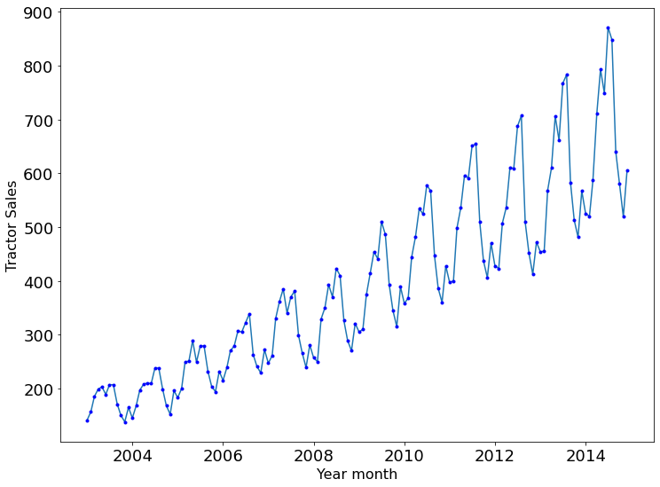

```python
fig, ax1 = plt.subplots(figsize=(12, 9))
ax1.plot_date( sales.index, sales['Number of Tractor Sold'],linestyle = 'solid',markeredgecolor = 'blue',markerfacecolor = 'blue', markersize = 3)
ax1.ticklabel_format(axis = 'y', style= 'sci',scilimits =(0,3))
ax1.set_xlabel('Year month',fontsize=16)
ax1.set_ylabel('Tractor Sales',fontsize=16)
plt.tick_params(labelsize=18)
plt.show()
```

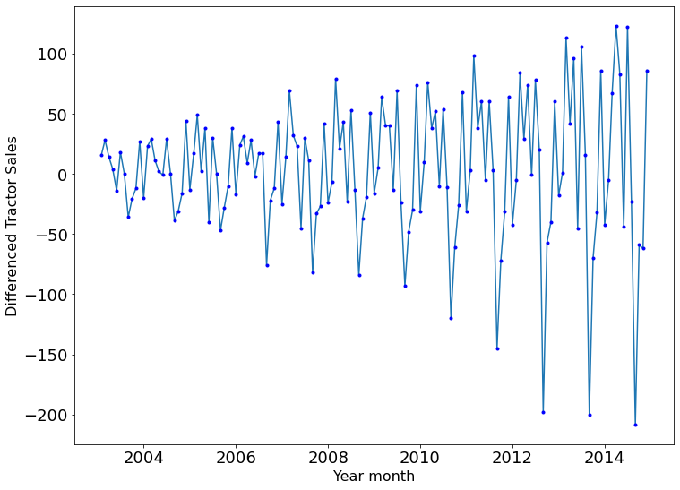

```python
# Step 2: Difference data to make data stationary on mean (remove trend)
sales['Differenced Tractor Sales'] = sales['Number of Tractor Sold'].diff(periods=1)
fig, ax1 = plt.subplots(figsize=(12, 9))
ax1.plot_date( sales.index, sales['Differenced Tractor Sales'],linestyle = 'solid',markeredgecolor = 'blue',markerfacecolor = 'blue', markersize = 3)
ax1.ticklabel_format(axis = 'y', style= 'sci',scilimits =(0,3))
ax1.set_xlabel('Year month',fontsize=16)
ax1.set_ylabel('Differenced Tractor Sales',fontsize=16)
plt.tick_params(labelsize=18)
plt.show()
```

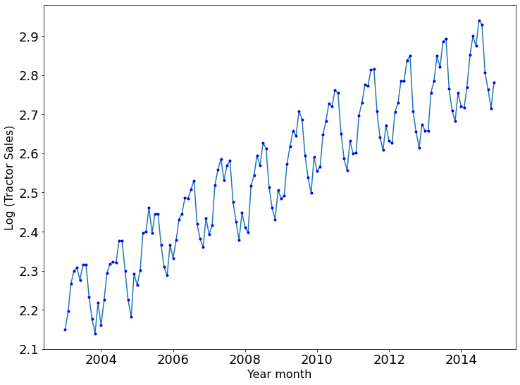

```python
# Step 3: log transform data to make data stationary on variance
sales['Log_Sales'] = np.log10(sales['Number of Tractor Sold'])
fig, ax1 = plt.subplots(figsize=(12, 9))
ax1.plot_date( sales.index, sales['Log_Sales'],linestyle = 'solid',markeredgecolor = 'blue',markerfacecolor = 'blue', markersize = 3)
ax1.ticklabel_format(axis = 'y', style= 'sci',scilimits =(0,3))
ax1.set_xlabel('Year month',fontsize=16)
ax1.set_ylabel('Log (Tractor Sales)',fontsize=16)
plt.tick_params(labelsize=18)
plt.show()
```

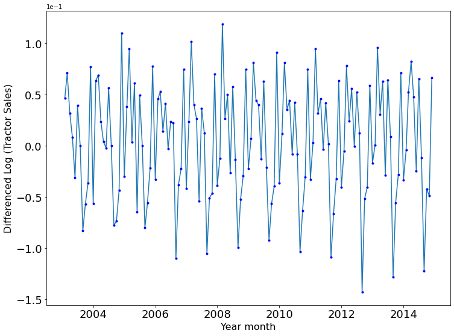

```python
sales['Diff_Log_Sales'] = sales['Log_Sales'].diff(periods=1)
fig, ax1 = plt.subplots(figsize=(12, 9))
ax1.plot_date( sales.index, sales['Diff_Log_Sales'],linestyle = 'solid',markeredgecolor = 'blue',markerfacecolor = 'blue', markersize = 3)
ax1.ticklabel_format(axis = 'y', style= 'sci',scilimits =(0,3))
ax1.set_xlabel('Year month',fontsize=16)
ax1.set_ylabel('Differenced Log (Tractor Sales)',fontsize=16)
plt.tick_params(labelsize=18)
plt.show()
```

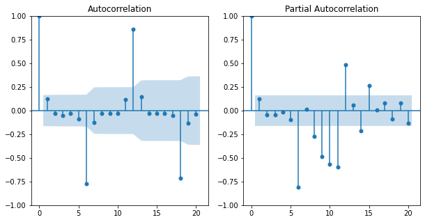

```python
_, acf_pacf_axs = plt.subplots(1,2,figsize=(10,5))
# lags refers to how far forward the graph plots
plot_acf(sales['Diff_Log_Sales'][1:].squeeze(), lags=20, ax=acf_pacf_axs[0])
plot_pacf(sales['Diff_Log_Sales'][1:].squeeze(), lags=20, ax=acf_pacf_axs[1])
plt.show()
```

```python
model = pm.auto_arima(
    sales['Log_Sales'],
    seasonal = True, m=12, suppress_warnings=True,
    maxiter=100, trace=True) # m=seasonal length
model.summary()
```

```
Performing stepwise search to minimize aic
 ARIMA(2,0,2)(1,1,1)[12] intercept   : AIC=-697.065, Time=1.05 sec
 ARIMA(0,0,0)(0,1,0)[12] intercept   : AIC=-578.708, Time=0.03 sec
 ARIMA(1,0,0)(1,1,0)[12] intercept   : AIC=-693.757, Time=0.79 sec
 ARIMA(0,0,1)(0,1,1)[12] intercept   : AIC=-643.271, Time=0.50 sec
 ARIMA(0,0,0)(0,1,0)[12]             : AIC=-372.956, Time=0.02 sec
 ARIMA(2,0,2)(0,1,1)[12] intercept   : AIC=-706.617, Time=1.63 sec
 ARIMA(2,0,2)(0,1,0)[12] intercept   : AIC=-676.406, Time=0.34 sec
 ARIMA(2,0,2)(0,1,2)[12] intercept   : AIC=-704.733, Time=5.43 sec
 ARIMA(2,0,2)(1,1,0)[12] intercept   : AIC=-700.528, Time=1.18 sec
 ARIMA(2,0,2)(1,1,2)[12] intercept   : AIC=-699.944, Time=2.17 sec
 ARIMA(1,0,2)(0,1,1)[12] intercept   : AIC=-708.050, Time=2.05 sec
 ARIMA(1,0,2)(0,1,0)[12] intercept   : AIC=-676.754, Time=0.11 sec
 ARIMA(1,0,2)(1,1,1)[12] intercept   : AIC=-698.176, Time=0.78 sec
 ARIMA(1,0,2)(0,1,2)[12] intercept   : AIC=-705.219, Time=4.13 sec
 ARIMA(1,0,2)(1,1,0)[12] intercept   : AIC=-702.104, Time=1.42 sec
 ARIMA(1,0,2)(1,1,2)[12] intercept   : AIC=-699.139, Time=1.81 sec
 ARIMA(0,0,2)(0,1,1)[12] intercept   : AIC=-676.642, Time=0.93 sec
 ARIMA(1,0,1)(0,1,1)[12] intercept   : AIC=-710.183, Time=1.03 sec
 ARIMA(1,0,1)(0,1,0)[12] intercept   : AIC=-678.506, Time=0.20 sec
 ARIMA(1,0,1)(1,1,1)[12] intercept   : AIC=-699.550, Time=1.10 sec
 ARIMA(1,0,1)(0,1,2)[12] intercept   : AIC=-707.164, Time=2.00 sec
 ARIMA(1,0,1)(1,1,0)[12] intercept   : AIC=-704.001, Time=0.92 sec
 ARIMA(1,0,1)(1,1,2)[12] intercept   : AIC=-699.114, Time=1.12 sec
 ARIMA(1,0,0)(0,1,1)[12] intercept   : AIC=-702.586, Time=0.86 sec
 ARIMA(2,0,1)(0,1,1)[12] intercept   : AIC=-707.910, Time=0.92 sec
 ARIMA(0,0,0)(0,1,1)[12] intercept   : AIC=-587.805, Time=0.21 sec
 ARIMA(2,0,0)(0,1,1)[12] intercept   : AIC=-710.038, Time=0.88 sec
 ARIMA(1,0,1)(0,1,1)[12]             : AIC=-704.124, Time=0.61 sec

Best model:  ARIMA(1,0,1)(0,1,1)[12] intercept
Total fit time: 34.246 seconds
```

SARIMAX Results

| Dep. Variable: | y | No. Observations: | 144 |
| --- | --- | --- | --- |
| Model: | SARIMAX(1, 0, 1)x(0, 1, 1, 12) | Log Likelihood | 360.092 |
| Date: | Mon, 10 Apr 2023 | AIC | -710.183 |
| Time: | 18:27:23 | BIC | -695.769 |
| Sample: | 01-01-2003 | HQIC | -704.326 |
|  | - 12-01-2014 |  |  |
| Covariance Type: | opg |  |  |

|  | coef | std err | z | P>\|z\| | [0.025 | 0.975] |
| --- | --- | --- | --- | --- | --- | --- |
| intercept | 0.0047 | 0.003 | 1.630 | 0.103 | -0.001 | 0.010 |
| ar.L1 | 0.9078 | 0.055 | 16.637 | 0.000 | 0.801 | 1.015 |
| ma.L1 | -0.3422 | 0.100 | -3.409 | 0.001 | -0.539 | -0.145 |
| ma.S.L12 | -0.5527 | 0.105 | -5.274 | 0.000 | -0.758 | -0.347 |
| sigma2 | 0.0002 | 2.58e-05 | 9.318 | 0.000 | 0.000 | 0.000 |

| Ljung-Box (L1) (Q): | 0.03 | Jarque-Bera (JB): | 7.47 |
| --- | --- | --- | --- |
| Prob(Q): | 0.86 | Prob(JB): | 0.02 |
| Heteroskedasticity (H): | 0.58 | Skew: | 0.06 |
| Prob(H) (two-sided): | 0.08 | Kurtosis: | 4.16 |

Warnings:  
[1] Covariance matrix calculated using the outer product of gradients (complex-step).

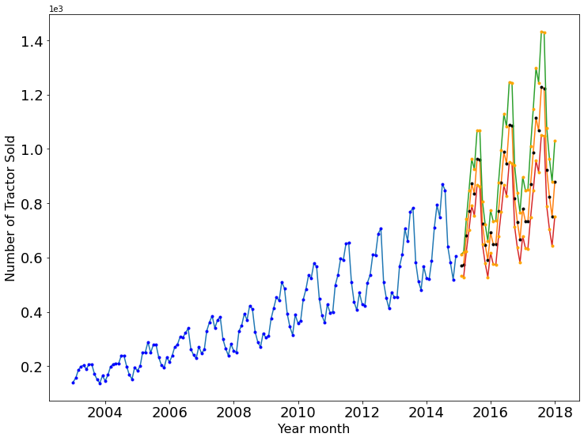

```python
pred, conf = model.predict(36, return_conf_int=True,alpha=0.05)

Test = pd.DataFrame()

Test['test_periods'] = pd.Series(pd.date_range('2015-01-01','2018-01-01', freq = 'M'))
Test['lower_bounds'] = [i[0] for i in conf ]
Test['upper_bounds'] = [i[1] for i in conf ]
Test['prediction'] = list(pred)

fig, ax1 = plt.subplots(figsize=(12, 9))
ax1.plot_date( sales.index, sales['Number of Tractor Sold'],linestyle = 'solid',markeredgecolor = 'blue',markerfacecolor = 'blue', markersize = 3)
ax1.plot_date( Test['test_periods'], 10**Test['prediction'], linestyle = 'solid',markeredgecolor = 'black',markerfacecolor = 'black', markersize = 3)
ax1.plot_date( Test['test_periods'], 10**Test['upper_bounds'], linestyle = 'solid',markeredgecolor = 'orange',markerfacecolor = 'orange', markersize = 3)
ax1.plot_date( Test['test_periods'], 10**Test['lower_bounds'], linestyle = 'solid',markeredgecolor = 'orange',markerfacecolor = 'orange', markersize = 3)
ax1.ticklabel_format(axis = 'y', style= 'sci',scilimits =(0,3))
ax1.set_xlabel('Year month',fontsize=16)
ax1.set_ylabel('Number of Tractor Sold',fontsize=16)
plt.tick_params(labelsize=18)
plt.show()
```

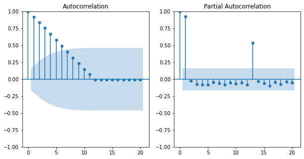

```python
# Step 7: Plot ACF and PACF for residuals of ARIMA model to ensure no more information is left for extraction

_, acf_pacf_resid_axs = plt.subplots(1,2,figsize=(10,5))
# lags refers to how far forward the graph plots
plot_acf(model.resid().squeeze(), lags=20, ax=acf_pacf_resid_axs[0])
plot_pacf(model.resid().squeeze(), lags=20, ax=acf_pacf_resid_axs[1])
plt.show()
```

#### 2.4.1 Univariate Time Series Techniques Summary

1. Determine whether the series is stationary
2. Plot ACF, PACF to determine seasonality
3. Conduct differencing if non-stationary, iterate until stationarity is achieved
4. Compare lags in ACF and PACF plots to identify the form of the model
5. Use of evaluation metrics to evaluate the models - MSE, MAD, MAPE, Akaike's Information Criterion (AIC), Bayesian Information Criterion (BIC)
   - Recall: Principle of parsimony in Data Science (BIC accounts for number of variables)
6. Ensure residuals are random
   - Ljung-Box Q Statistics: Plot ACF and PACF of the **residuals**. Approximately distributed as a $\chi$-square random variable with m-r degrees of freedom where r is the total number of parameters estimated in the ARIMA model
7. Recall that forecasts further into the horizon are subjected to higher uncertainty. Forecasts should be recomputed as more data becomes available. This should be factored into the model monitoring process, which is not covered in today's session

| Pros | Cons |
| --- | --- |
| Provide accurate short-range forecasts | A relatively large amount of data is required (> 50 for non-seasonal data and 6-10 years of seasonal data) |
| Quite flexible and can represent a wide range of characteristics of time series | No easy way to update the parameters as new data become available |
| Formal procedures for testing the adequacy of the model are available |  |
| Forecasts and prediction intervals follow directly from the fitted model |  |

#### 2.5 Fourier Transformations (!Technical!)

- Fourier Transformations decomposes any function into sines and cosines (or waves)
- Widely used in time series analysis for understanding the periodicity and seasonality of a signal
- Converts time-domain to frequency-domain, which is obtained by decomposing it into a sum of sinusoidal functions of different frequencies, each of its own amplitude and phase.

Discrete Fourier Transform

- Converts data to sequence of discrete frequencies.
- Use `np.fft` (Fast Fourier Transform) to compute the DFT. FFT is a faster version of the DFT from an algorithmic standpoint.
- The values at which the power spectrum plot peaks, demonstrates the strength of each frequency component. This translates loosely to the periodicity of a signal, or seasonality in time series.

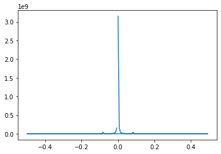

```python
### Apply FFT and take absolute values
fft = np.abs(np.fft.fft(
    sales['Number of Tractor Sold'])
    )

### Compute the power spectrum
power = fft**2

### Compute the frequencies
freq = np.fft.fftfreq(len(power), d=1)  # assumes index is 1 unit apart here

# Plot the results
plt.plot(freq, power)
plt.show()
```

### 3. Multivariate Time Series

Multivariate time series analysis, as its name suggests, has multiple time-dependent variables, i.e.the values of variable X at time $t$ may be dependent on variable $Y$ at time $t-1$.  
Vector Autoregression (VAR) and Vector Error Correction Model (VECM) are two popular techniques for analyzing multivariate time series data.

VAR Model  
Generalizes the univariate AR model, to accomodate multiple time series, modeled as a system of interdependent linear equations.  
Assumption:

1. Each variable is stationary: Each variable is a function of its own lagged values,
2. There exists a linear relationship between their current and past values  
   Use of *Granger Causality tests* can determine if one variable can beused as a predictor of another variable.

VECM Model  
Extends VAR to accomodate non-stationary time series data.  
Variables are first differenced to till stationary, and then the VAR model is run.  
Includes an error correction term, which captures the long-run equilibrium relationship among the variables.  
Useful for data with cointegration, even if the variables are not directly causally related

VAR and VECM models are estimated using AIC and BIC criteria. (Lower AIC = Better Model)

```python
from statsmodels.tools.eval_measures import rmse, aic
from statsmodels.tsa.stattools import grangercausalitytests
from statsmodels.tsa.vector_ar.vecm import select_coint_rank

mv_data = pd.read_excel(
    os.path.join(
        DATA_DIR, "multivariate-timeseries.xlsx"
    )
)
mv_data.head()
```

|  | Date | Gold | Silver | Crude Oil |
| --- | --- | --- | --- | --- |
| 0 | 2018-03-01 | 1302.9 | 16.2 | 60.99 |
| 1 | 2018-03-02 | 1321.1 | 16.39 | 61.25 |
| 2 | 2018-03-05 | 1318.1 | 16.34 | 62.57 |
| 3 | 2018-03-06 | 1333.6 | 16.72 | 62.6 |
| 4 | 2018-03-07 | 1326 | 16.43 | 61.15 |

```python
mv_data = mv_data.replace({'-':np.nan}).ffill()
mv_data.set_index('Date', inplace = True)
mv_data = mv_data.astype(float)
mv_data['Gold'] = mv_data['Gold']/100 # Scaling of gold prices to compare on the same cale

mv_train = mv_data[mv_data.index.year < 2022]
mv_test = mv_data[mv_data.index.year >= 2022]
```

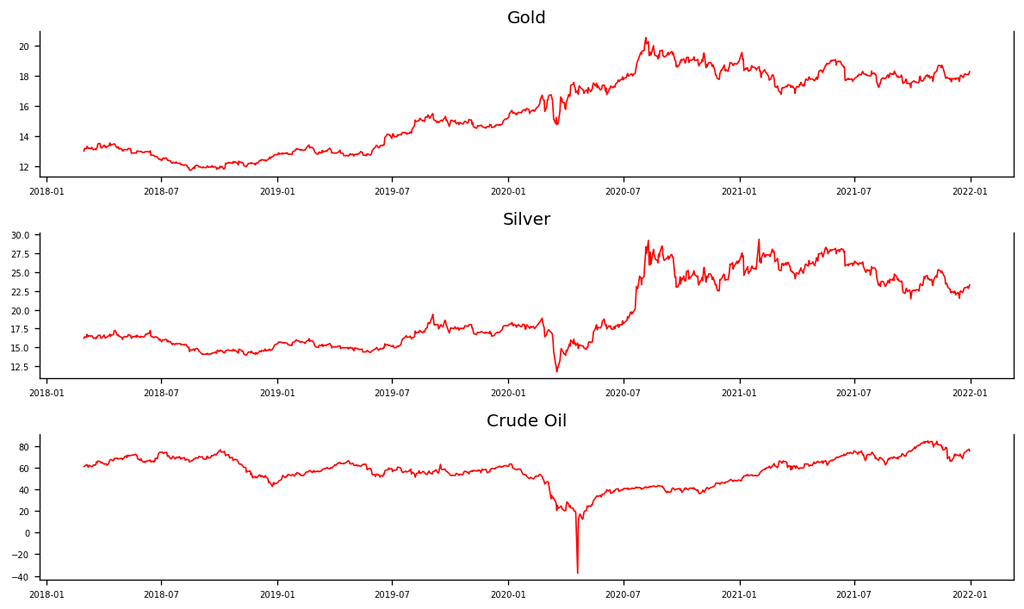

```python
fig, axes = plt.subplots(3, 1, dpi=120, figsize=(10,6))
for i, ax in enumerate(axes.flatten()):
    data = mv_train[mv_train.columns[i]]
    ax.plot(data, color='red', linewidth=1)
    ax.set_title(mv_train.columns[i])
    ax.spines["top"].set_alpha(0)
    ax.tick_params(labelsize=6)
plt.tight_layout()
```

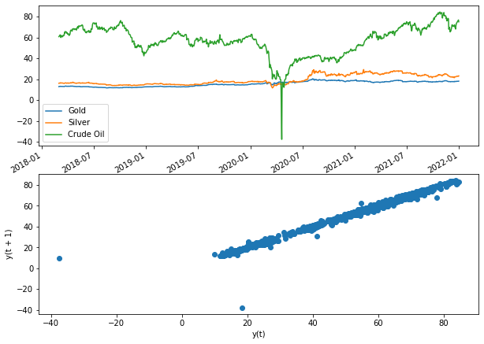

```python
fig, mv_axs = plt.subplots(2, 1, figsize=(10,8))
mv_train.plot(ax=mv_axs[0])
pd.plotting.lag_plot(mv_train, ax=mv_axs[1])
plt.show()
```

```python
mv_train[mv_train['Crude Oil'] < 0]
mv_train = mv_train[mv_train.index != '2020-04-20']
```

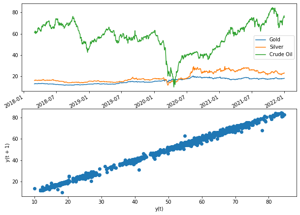

```python
fig, mv_axs = plt.subplots(2, 1, figsize=(10,8))
mv_train.plot(ax=mv_axs[0])
pd.plotting.lag_plot(mv_train, ax=mv_axs[1])
plt.show()
```

Clear outliers in the data when the price of crude oil dipped. Otherwise, outliers are insignificant

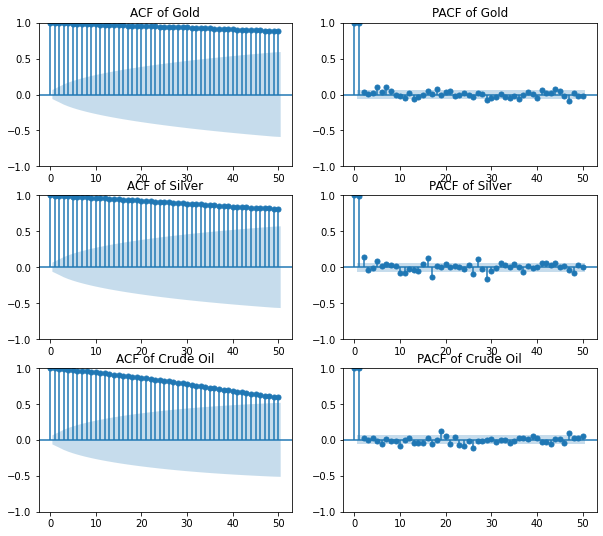

```python
_, mv_acf_pacf = plt.subplots(3,2,figsize=(10,9))
for i,ax_i in enumerate(mv_acf_pacf):
    colname = mv_train.columns[i]
    plot_acf(mv_train[colname], lags = 50, ax=ax_i[0], title='ACF of {}'.format(colname))
    plot_pacf(mv_train[colname], lags = 50, ax=ax_i[1], title='PACF of {}'.format(colname))
plt.show()
```

The ACF plots indicate a presence of positive correlation

```python
for col in mv_train.columns:
    print('ADF Test for {}: {}'.format(col, sm_adf(mv_train[col])))
```

```
ADF Test for Gold: (False, Test Statistic                  -0.757152
p-value                          0.831386
#lags used                              6
number of observations used           961
AIC                           -758.424828
critical_value (1%)             -3.437173
critical_value (5%)             -2.864552
critical_value (10%)            -2.568374
dtype: object)
ADF Test for Silver: (False, Test Statistic                   -1.313951
p-value                           0.622766
#lags used                              16
number of observations used            951
AIC                            1089.951136
critical_value (1%)              -3.437245
critical_value (5%)              -2.864584
critical_value (10%)             -2.568391
dtype: object)
ADF Test for Crude Oil: (False, Test Statistic                  -1.356301
p-value                          0.603037
#lags used                              0
number of observations used           967
AIC                            3349.08382
critical_value (1%)             -3.437131
critical_value (5%)             -2.864534
critical_value (10%)            -2.568364
dtype: object)
```

Original time series are non-stationary according to the augmented Dickey Fuller tests.  
Granger Causality tests specifies that if a variable $X$ causes $Y$  
$H_0$: Lags of X do not Granger cause Y  
$H_1$: Lags of X Granger cause Y  
Assumptions:

- Both $x_1$ and $x_2$ are stationary
- There exists a linear relationship between their past and current values

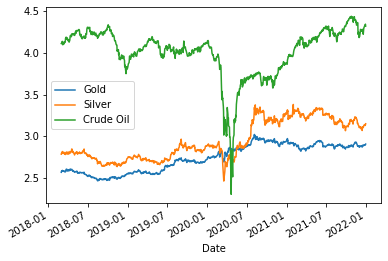

```python
mv_train_log = np.log(mv_train)
mv_train_log_diff = mv_train_log.diff().dropna()
mv_train_log.plot()
plt.show()
```

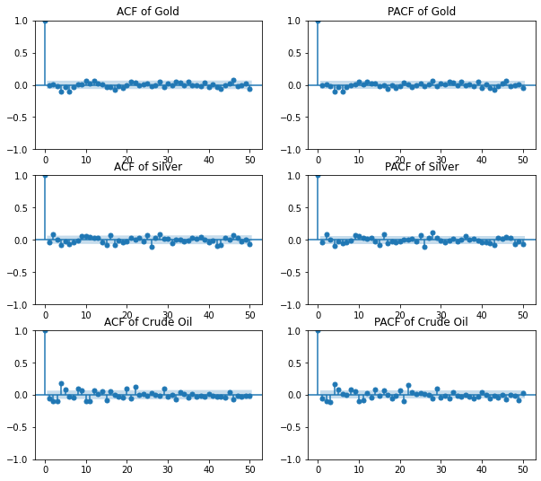

```python
_, mv_acf_pacf = plt.subplots(3,2,figsize=(10,9))
for i,ax_i in enumerate(mv_acf_pacf):
    colname = mv_train.columns[i]
    plot_acf(mv_train_log_diff[colname], lags = 50, ax=ax_i[0], title='ACF of {}'.format(colname))
    plot_pacf(mv_train_log_diff[colname], lags = 50, ax=ax_i[1], title='PACF of {}'.format(colname))
plt.show()
```

```python
for col in mv_train.columns:
    print('ADF Test for {}: {}'.format(col, sm_adf(mv_train_log_diff[col])))
```

```
ADF Test for Gold: (True, Test Statistic                  -15.376403
p-value                                0.0
#lags used                               5
number of observations used            961
AIC                           -6077.222967
critical_value (1%)              -3.437173
critical_value (5%)              -2.864552
critical_value (10%)             -2.568374
dtype: object)
ADF Test for Silver: (True, Test Statistic                   -7.311054
p-value                                0.0
#lags used                              16
number of observations used            950
AIC                           -4729.698877
critical_value (1%)              -3.437252
critical_value (5%)              -2.864587
critical_value (10%)             -2.568392
dtype: object)
ADF Test for Crude Oil: (True, Test Statistic                   -5.713252
p-value                           0.000001
#lags used                              21
number of observations used            945
AIC                           -3451.510509
critical_value (1%)              -3.437289
critical_value (5%)              -2.864603
critical_value (10%)             -2.568401
dtype: object)
```

The datasets are now stationary and can be tested for Granger causality.

```python
def grangercausalitymatrix(df, com_ls = combinations(mv_train.columns, 2), test='ssr_chi2test', verbose=True):
    GC_results = []

    for unique_pair in com_ls:
        pair = list(unique_pair)
        pairs = [pair, pair[::-1]]
        for pair in pairs:
            if verbose:
                print("For {}".format(pair))

            gc_tmp = grangercausalitytests(
                df[pair],
                maxlag=15, addconst=True, verbose=verbose
            )
            res = pd.DataFrame(
                [*pair, min(
                    map(lambda x: x[0][test][1], gc_tmp.values())
                )]
            ).T
            GC_results.append(res)

    gc_results = pd.concat(GC_results).pivot(index=0, columns=1).fillna(1)
    gc_results.index.name = None
    gc_results.columns = list(map(lambda x: x[1], gc_results.columns))
    return gc_results

grangercausalitymatrix(mv_train_log_diff, verbose=False)
```

|  | Crude Oil | Gold | Silver |
| --- | --- | --- | --- |
| Crude Oil | 1.000000 | 2.934996e-07 | 0.010251 |
| Gold | 0.171795 | 1.000000e+00 | 0.000164 |
| Silver | 0.131970 | 4.899923e-04 | 1.000000 |

Reading *index Granger causes column name*,  
We can conclude the following:

- Gold Granger causes Silver (p-value < 0.001),
- Silver also Granger causes Gold (p-value <0.0005),
- Gold does not Granger cause Crude Oil but Crude Oil Granger causes Gold
- Silver does not Granger cause Crude Oil but Crude Oil Granger causes Silver

```python
def invert_transformations(forecasted):
    initial_vals = pd.DataFrame(mv_train_log.iloc[0]).T
    train_values = mv_train_log_diff
    forecasted_values = pd.DataFrame(forecasted, index=mv_test.index, columns=mv_train_log.columns)
    all_values = pd.concat([initial_vals, train_values, forecasted_values])
    return np.exp(all_values.cumsum())[-len(forecasted):]
```

```python
### VAR Model
VAR_model = tsa.VAR(endog=mv_train_log_diff)
VAR_results = VAR_model.select_order(15)
VAR_results = VAR_model.fit(maxlags=3)#, ic='aic')

### Forecast using VAR model
lag_order = VAR_results.k_ar
forecast_input = mv_train_log_diff.values[-lag_order:]
var_fc = VAR_results.forecast(y=forecast_input, steps=len(mv_test))
var_fc_inverted = pd.concat
print(VAR_results.summary())

inverted_forecasts = invert_transformations(var_fc)
### Compute RMSE of VAR model
var_rmse = rmse(inverted_forecasts.values, mv_test.values)

print(f"VAR RMSE: {var_rmse}")
```

```
  Summary of Regression Results
==================================
Model:                         VAR
Method:                        OLS
Date:           Mon, 10, Apr, 2023
Time:                     18:27:29
--------------------------------------------------------------------
No. of Equations:         3.00000    BIC:                   -24.4104
Nobs:                     964.000    HQIC:                  -24.5043
Log likelihood:           7765.31    FPE:                2.15210e-11
AIC:                     -24.5620    Det(Omega_mle):     2.08649e-11
--------------------------------------------------------------------
Results for equation Gold
===============================================================================
                  coefficient       std. error           t-stat            prob
-------------------------------------------------------------------------------
const                0.000324         0.000312            1.040           0.298
L1.Gold              0.096441         0.051940            1.857           0.063
L1.Silver           -0.057816         0.025803           -2.241           0.025
L1.Crude Oil        -0.001625         0.007966           -0.204           0.838
L2.Gold             -0.077501         0.052165           -1.486           0.137
L2.Silver            0.049940         0.025908            1.928           0.054
L2.Crude Oil         0.005393         0.007920            0.681           0.496
L3.Gold              0.005172         0.052229            0.099           0.921
L3.Silver           -0.012003         0.025936           -0.463           0.644
L3.Crude Oil         0.003807         0.007944            0.479           0.632
===============================================================================

Results for equation Silver
===============================================================================
                  coefficient       std. error           t-stat            prob
-------------------------------------------------------------------------------
const                0.000228         0.000632            0.361           0.718
L1.Gold              0.355155         0.105283            3.373           0.001
L1.Silver           -0.177573         0.052303           -3.395           0.001
L1.Crude Oil         0.020576         0.016146            1.274           0.203
L2.Gold             -0.063310         0.105738           -0.599           0.549
L2.Silver            0.100898         0.052517            1.921           0.055
L2.Crude Oil         0.005241         0.016054            0.326           0.744
L3.Gold              0.198963         0.105867            1.879           0.060
```

[output cut: 14 more lines]

```
L2.Crude Oil        -0.132286         0.032320           -4.093           0.000
L3.Gold             -0.523329         0.213130           -2.455           0.014
L3.Silver            0.202715         0.105836            1.915           0.055
L3.Crude Oil        -0.126801         0.032416           -3.912           0.000
===============================================================================

Correlation matrix of residuals
                 Gold    Silver  Crude Oil
Gold         1.000000  0.782308   0.077480
Silver       0.782308  1.000000   0.162939
Crude Oil    0.077480  0.162939   1.000000



VAR RMSE: [ 1.61498583  3.70416547 19.82292019]
```

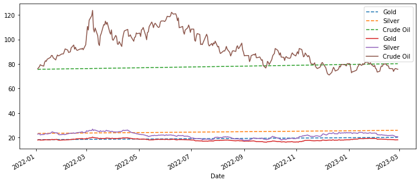

```python
fig, var_ax = plt.subplots(sharex=True, figsize=(12,5))
inverted_forecasts.plot(style='--', ax=var_ax)
mv_test.plot(ax=var_ax)
plt.xlabel('Date')
plt.show()
```

```python
vec_rank1 = select_coint_rank(
    mv_train, det_order = 1, k_ar_diff = 1, method = 'trace', signif=0.01
    ) #methods = trace, maxeig

vec_rank2 = select_coint_rank(
    mv_train, det_order = 1, k_ar_diff = 1, method = 'maxeig', signif=0.01
    )

print(vec_rank1.summary())
print(vec_rank2.summary())
```

```
Johansen cointegration test using trace test statistic with 1% significance level
=====================================
r_0 r_1 test statistic critical value
-------------------------------------
  0   3          37.21          41.08
-------------------------------------
Johansen cointegration test using maximum eigenvalue test statistic with 1% significance level
=====================================
r_0 r_1 test statistic critical value
-------------------------------------
  0   1          21.68          29.26
-------------------------------------
```

```python
### VECM model
vecm_model = tsa.VECM(mv_train, k_ar_diff = 9, coint_rank=3, deterministic='ci')
vecm_results = vecm_model.fit()

### Forecast using VECM model
vecm_fc = vecm_results.predict(steps=len(mv_test))

### Compute RMSE of VECM model
vecm_rmse = rmse(vecm_fc, mv_test.values)


print(f"VECM RMSE: {vecm_rmse}")
```

```
VECM RMSE: [ 1.40309095  3.85405483 30.94019346]
```

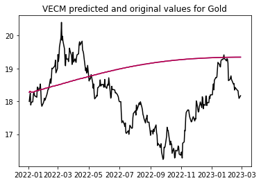

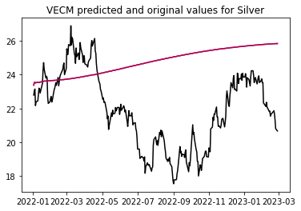

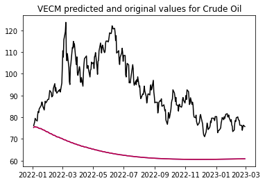

```python
vecm_forecast, vecm_lower, vecm_upper = vecm_results.predict(len(mv_test), 0.05)
vecm_forecast = pd.DataFrame(vecm_forecast, index=mv_test.index, columns=mv_test.columns)
vecm_lower = pd.DataFrame(vecm_lower, index=mv_test.index, columns=mv_test.columns)
vecm_upper = pd.DataFrame(vecm_upper, index=mv_test.index, columns=mv_test.columns)

for prod in mv_test.columns:
    plt.figure()
    plt.plot(mv_test.index, mv_test[prod], color='k', label='Original')
    plt.plot(vecm_forecast.index, vecm_forecast[prod], color='blue', label='Forecasted')
    plt.plot(vecm_lower.index, vecm_forecast[prod], color='red', alpha=0.5, label='Lower Limit')
    plt.plot(vecm_upper.index, vecm_forecast[prod], color='red', alpha=0.5, label='Upper Limit')
    plt.title('VECM predicted and original values for {}'.format(prod))
    plt.show()
```

The predictions become less accurate over time.

### 4. Group Project

Consider one of the following datasets:

- Beijing Multi-Site Air Quality Data,
- Pasir Panjang Rainfall Data, (or other rainfall data from [Meteorological Service Singapore](http://www.weather.gov.sg/climate-historical-daily/))
- HDB Resale Prices
- Stock data from Yahoo! Finance

or any dataset from the [UCI Machine Learning Repository](https://archive.ics.uci.edu/ml/datasets.php?format=&task=&att=&area=&numAtt=10to100&numIns=&type=ts&sort=nameUp&view=table), [The UEA & UCR Time Series Classification Repository](https://www.timeseriesclassification.com/)

Using the time series dataset, conduct a time series decomposition and analysis of the dataset.

At the end of the session, present your findings of the dataset.

### Helpful Resources:

- [Forecasting: Principles and Practice](https://otexts.com/fpp2/)
- [Jeffrey Yau: Time Series Forecasting using Statistical and Machine Learning Models](https://www.youtube.com/watch?v=_vQ0W_qXMxk)
- [A Very Short Course on Time Series Analysis: Fourier Transform](https://bookdown.org/rdpeng/timeseriesbook/the-fourier-transform.html)